# Community_detection_project

## Community detection using Louvain algorithm

### What is the Louvain community detection model?

The Louvain algorithm is a greedy optimization method that attempts to optimize the "modularity" of a partition of the network (for more details: https://perso.uclouvain.be/vincent.blondel/research/louvain.html). The idea behing the concept of modularity is that a community is a sub-graph which is not random and modularity is a metric that measures how far a partition is compared to a random graph. The optimisation model will try to find the partition which maximizes modularity (for more details regarding the mathematical formula of modularity, check out https://en.wikipedia.org/wiki/Modularity_%28networks%29)

We will use the Louvain model to group products which are similar to one another from the product_proximity.txt file.

### Import packages

```python
import os
import sys
import math
import random
import operator
import itertools
import pprint as pp
import numpy as np
import pandas as pd
import seaborn as sns
import networkx as nx
from itertools import combinations
import matplotlib.pyplot as plt
from IPython.display import Image
from IPython.core.display import HTML
from networkx.algorithms import community
import community
from community import community_louvain
from collections import defaultdict
import matplotlib.pyplot as plt
from scipy import linalg
```

### Product proximity data set description

The dataset product_proximity.txt contains data on a set of products and a proximity measure that measures how close two products are (based on correlation of exports---but it is not so important how this was derived). The first two columns represent the node numbers (representing the products) and the third column, the weight (the proximity) of the nodes.

### Graph the "product network"

In the graph below, the size of the node depends on the number of inward edges (edges coming from another product) and the size of the edge depends on the proximity measure assigned (or weights) between the two products.

[figure not shown]

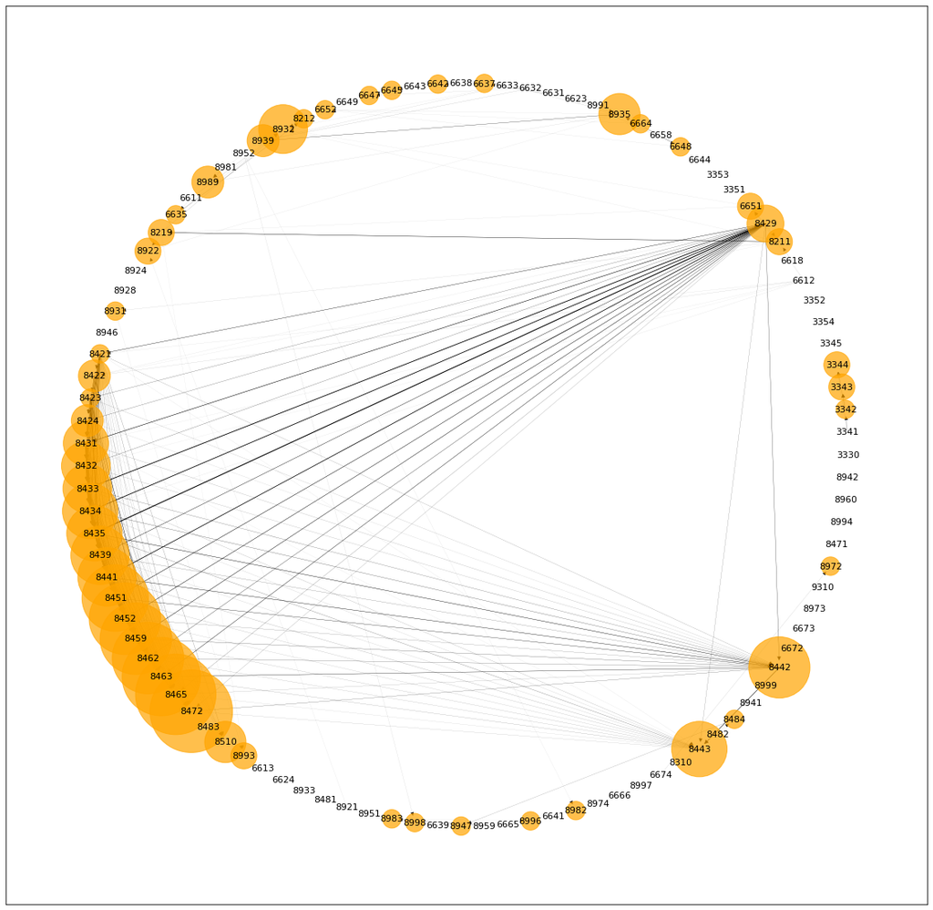

```python
G0 = nx.read_edgelist("./" + "product_proximity.txt", nodetype=int, data=(('weight',float),), create_using=nx.DiGraph()  )

G1 = G0.copy()

#pos = nx.spring_layout(G0, seed=1)
pos = nx.circular_layout(G1)

plt.axis('off')
plt.title("Product Proximity", fontsize=16)
plt.figure(figsize=(20,20))

#Filter values in terms of proximity:
high_values = [(u,v) for (u,v,d) in G0.edges(data=True) if d['weight']>=0.5]
for x in G0.edges:
    if x not in high_values:
        G1.remove_edge(x[0],x[1])

# Format node sizes:

# get the inward degree for each node and store them as a list of (node_number, degree)
in_deg = G1.in_degree()
# Multiply the node degree to 1000 as the node size
in_deg = [int(in_deg[node])*500 for node in G1.nodes()]


# Format weights:

weights = []
for edge, weight in nx.get_edge_attributes(G1,'weight').items():
    weights.append(weight)

#weighted_egdes = [(0.1+abs(weight))**20 for weight in weights]
weighted_egdes = [(0.2+abs(weight))**10 for weight in weights]


nx.draw_networkx_nodes(G1, pos, node_size=in_deg,  cmap="spring", alpha=0.7,node_color="orange")
nx.draw_networkx_edges(G1, pos, edge_list = G1.edges, width = weighted_egdes, style = 'solid', edge_color = 'black')
nx.draw_networkx_labels(G1,pos,font_size=11)
plt.show(G1)
```

### Community detection

We would like to identify clusters of products that are similar to each other. Let's run the Louvain community detection algorithm to identify clusters:

```python
G3 = nx.read_edgelist("./" + "product_proximity.txt", nodetype=int, data=(('weight',float),), create_using=nx.Graph()  )
```

```python
product_louvain = community_louvain.best_partition(G3)
community.modularity(product_louvain, G3)
```

```
0.39554135443972616
```

We see that the best partition has a modularity of 0.4 roughly. Below are the values assigned to each node/product:

```python
product_louvain.values()
```

```
dict_values([0, 0, 0, 0, 0, 0, 0, 0, 1, 2, 2, 1, 2, 2, 2, 2, 2, 2, 2, 2, 3, 2, 2, 2, 2, 2, 2, 2, 2, 2, 2, 2, 2, 2, 2, 2, 3, 3, 2, 2, 2, 2, 2, 2, 2, 2, 2, 1, 1, 1, 1, 1, 1, 1, 1, 1, 1, 1, 1, 1, 1, 1, 1, 1, 1, 2, 1, 1, 2, 2, 2, 3, 2, 2, 2, 3, 2, 3, 2, 3, 2, 2, 3, 2, 3, 1, 3, 3, 1, 3, 3, 2, 3, 1, 3, 3,…
```

Let's now graph the different clusters of products in terms of proximity:

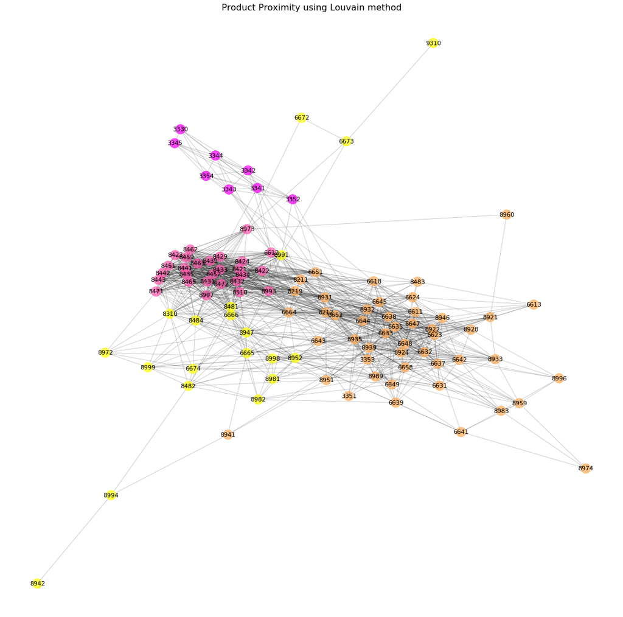

```python
pos = nx.spring_layout(G3, seed=1)
plt.figure(figsize=(20,20))
plt.axis('off')
plt.title("Product Proximity using Louvain method", fontsize=16)
nx.draw_networkx_nodes(G3, pos, node_size=300, cmap="spring", alpha=0.7,node_color=list(product_louvain.values()))
nx.draw_networkx_edges(G3, pos, alpha=0.2)
nx.draw_networkx_labels(G3,pos,font_size=11)
plt.show(G3)
```

We see that there are four main groups of products which are similar to one another!

### Test/assessment of the model

We store the results in a dataframe:

```python
df_louvain_results = pd.DataFrame(product_louvain.values())
df_louvain_results['node'] = product_louvain.keys()
df_louvain_results.rename(columns = {0:'category predicted'}, inplace = True)
df_louvain_results['category predicted'].unique()
```

```
array([0, 1, 2, 3])
```

To test the accuracy of the Louvain model, we load the actual categorization and compare the results with the ones we obtained from the Louvain model

```python
data_product = pd.read_csv('product_categories.txt', sep=" ", header=None)
df = data_product[[0,10,12]]
df = df.rename(columns = {0:'node', 10:'category',12:'description'})
df_2 = df[~df['node'].str.contains("X", na=False)]
df_3 = df_2[~df_2['node'].str.contains("A", na=False)]
df_3['node'] = df_3['node'].astype(int)
df_3.dtypes
```

```
node            int64
category       object
description    object
dtype: object
```

```python
df_real_clusters = df_3.merge(df_louvain_results, on = 'node')
df_real_clusters.head()
```

|  | node | category | description | category predicted |
| --- | --- | --- | --- | --- |
| 0 | 3330 | 1 | Petroleum | 0 |
| 1 | 3341 | 1 | Petroleum | 0 |
| 2 | 3342 | 1 | Petroleum | 0 |
| 3 | 3343 | 1 | Petroleum | 0 |
| 4 | 3344 | 1 | Petroleum | 0 |

We observe that there are two actual categories of products: Petroleum and Labor Intensive products

```python
df_real_clusters['category'].unique()
```

```
array(['1', '7'], dtype=object)
```

```python
df_real_clusters['description'].unique()
```

```
array(['Petroleum', 'Labor Intensive'], dtype=object)
```

```python
df_real_clusters.groupby('category')['category predicted'].value_counts()
```

```
category  category predicted
1         0                      8
          2                      2
7         2                     46
          1                     27
          3                     20
Name: category predicted, dtype: int64
```

With community detection algorithms such as Louvain, we observe that the accuracy on category 1 (oil and petroleum products) is high unlike for category 7 (labor intensive products) where we see that the there are many different categories predicted. We could assume that it is harder for an algorithmm to predict the category of labor intensive products as it is a really vast and large product category. By running the Louvain algorithm, we observe that it returns 3 different communities for the labor-intensive category, which is strenghtening the point we just made that the labor-intensive category should have many diverse clusters within itself.